# Reproducibility Report: Group A Choice 3

Jiwon Byun

For this exercise, please try to reproduce the results from Experiment 6 of the associated paper (Shah, Shafir, & Mullainathan, 2015). The PDF of the paper is included in the same folder as this Rmd file.

#### Methods summary:

The authors were interested in the effect of scarcity on people’s consistency of valuation judgments. In this study, participants played a game of Family Feud and were given either 75 s (budget - “poor” condition) or 250 s (budget - “rich” condition) to complete the game. After playing the game, participants were either primed to think about a small account of time necessary to play one round of the game (account -“small” condition) or a large account (their overall time budget to play the entire game, account - “large” condition.) Participants rated how costly it would feel to lose 10s of time to play the game. The researchers were primarily interested in an interaction between the between-subjects factors of scarcity and account, hypothesizing that those in the budget - “poor” condition would be more consistent in their valuation of the 10s regardless of account in comparison with those in the budget - “rich” condition. The authors tested this hypothesis with a 2x2 between-subjects ANOVA.

#### Target outcomes:

Below is the specific result you will attempt to reproduce (quoted directly from the results section of Experiment 6):

> “One participant was excluded because of a computer malfunction during the game. Time-rich participants rated the loss as more expensive when they thought about a small account (M = 8.31, 95% CI = [7.78, 8.84]) than when they thought about a large account (M = 6.50, 95% CI = [5.42, 7.58]), whereas time-poor participants’ evaluations did not differ between the small-account condition (M = 8.33, 95% CI = [7.14, 9.52]) and the large account condition (M = 8.83, 95% CI = [7.97, 9.69]). A 2 (scarcity condition) × 2 (account condition) analysis of variance revealed a significant interaction, F(1, 69) = 5.16, p < .05, ηp2 = .07.” (Shah, Shafir & Mullainathan, 2015) ——

## Step 1: Load packages

```r
library(tidyverse) # for data munging
library(knitr) # for kable table formating
library(haven) # import and export 'SPSS', 'Stata' and 'SAS' Files
library(readxl) # import excel files
library(Rmisc)
library(purrr)
library(broom)
library(car)
library(lsr)

# #optional packages:
# library(afex) #anova functions
# library(langcog) #95 percent confidence intervals
```

# Step 2: Load data

```r
# Just Experiment 6
data <- read_excel("data/study 6-accessible-feud.xlsx")
```

# Step 3: Tidy data

The data are already tidy as provided by the authors.

```r
# view the structure of the data
str(data)
```

```
## tibble [74 × 14] (S3: tbl_df/tbl/data.frame)
##  $ Subject: num [1:74] 6 10 18 22 26 34 38 42 46 50 ...
##  $ Cond   : num [1:74] 0 0 0 0 0 0 0 0 0 0 ...
##  $ Slack  : num [1:74] 0 0 0 0 0 0 0 0 0 0 ...
##  $ Large  : num [1:74] 0 0 0 0 0 0 0 0 0 0 ...
##  $ tmest  : num [1:74] 15 15 15 7 15 15 15 15 10 40 ...
##  $ expense: num [1:74] 10 7 11 9 4 11 5 9 6 10 ...
##  $ error  : num [1:74] 0 0 0 0.533 0 ...
##  $ ...8   : logi [1:74] NA NA NA NA NA NA ...
##  $ ...9   : logi [1:74] NA NA NA NA NA NA ...
##  $ ...10  : chr [1:74] NA NA "Average of expense" "Row Labels" ...
##  $ ...11  : chr [1:74] NA NA "Column Labels" "0" ...
##  $ ...12  : num [1:74] NA NA NA 1 8.95 ...
##  $ ...13  : chr [1:74] NA NA NA "(blank)" ...
##  $ ...14  : chr [1:74] NA NA NA "Grand Total" ...
```

# Step 4: Run analysis

## Pre-processing

> One participant was excluded because of a computer malfunction during the game (Shah, Shafir, & Mullainathan, 2015, p. 408)

Note: The original paper does not identify the participant that was excluded, but it was later revealed through communication with the authors that it was participant #16. The exclusion is performed below.

```r
# Participant #16 should be dropped from analysis
excluded <- "16"

d <- data %>%
  filter(!Subject %in% excluded) #participant exclusions

d <- d %>%
  mutate(Slack = as.factor(Slack)) %>%
  mutate(Large = as.factor(Large))
```

## Descriptive statistics

> Time-rich participants rated the loss as more expensive when they thought about a small account (M = 8.31, 95% CI = [7.78, 8.84]) than when they thought about a large account (M = 6.50, 95% CI = [5.42, 7.58]), whereas time-poor participants’ evaluations did not differ between the small-account condition (M = 8.33, 95% CI = [7.14, 9.52]) and the large- account condition (M = 8.83, 95% CI = [7.97, 9.69]). (Shah, Shafir, & Mullainathan, 2015, p. 408)

```r
# reproduce the above results here
#require(purrr)
#d %>% split(.$Cond) %>% map(summary)

require(dplyr)

#d_desc <- d %>%
#  dplyr::group_by(Cond) %>%
#  dplyr::summarise(N = n(),
#                   mean = mean(expense),
#                   low_ci = t.test(expense, conf.level=0.95)$conf.int[1],
#                   upp_ci = t.test(expense, conf.level=0.95)$conf.int[2])
#d_desc


# first t-test (time-rich)
d_t1 <- d %>%
  filter(Cond == 1 | Cond == 3)
t1 <- t.test(expense ~ Cond, data = d_t1, alternative = "two.sided", paired = F, conf.level = 0.95)


# second t-test (time-poor)
d_t2 <- d %>%
  filter(Cond == 2 | Cond == 0)
t2 <- t.test(expense ~ Cond, data = d_t2, alternative = "two.sided", paired = F, conf.level = 0.95)


tab <- map_df(list(t1, t2), tidy)
tab <- tab %>% add_column("group" = c("Time-rich", "Time-poor"))
tab <- tab %>% select(c("group", "estimate", "estimate1", "estimate2", "statistic", "p.value", "conf.low", "conf.high", "alternative"))
kable(tab, caption = "t-test results for Time-rich and Time-poor participants")
```

t-test results for Time-rich and Time-poor participants

| group | estimate | estimate1 | estimate2 | statistic | p.value | conf.low | conf.high | alternative |
| --- | --- | --- | --- | --- | --- | --- | --- | --- |
| Time-rich | 1.8125 | 8.312500 | 6.500000 | 2.9600218 | 0.0067238 | 0.5502087 | 3.074791 | two.sided |
| Time-poor | -0.5000 | 8.333333 | 8.833333 | -0.6684931 | 0.5081985 | -2.0183522 | 1.018352 | two.sided |

```r
require(Rmisc)
d_desc <- d %>%
  dplyr::group_by(Cond) %>%
  dplyr::summarise(N = n(),
                   mean = mean(expense),
                   low_ci = CI(expense)[3],
                   upp_ci = CI(expense)[1])
kable(d_desc, caption = "Descriptive statistics for each condition")
```

Descriptive statistics for each condition

| Cond | N | mean | low_ci | upp_ci |
| --- | --- | --- | --- | --- |
| 0 | 21 | 8.333333 | 7.067489 | 9.599178 |
| 1 | 16 | 8.312500 | 7.737971 | 8.887028 |
| 2 | 18 | 8.833333 | 7.910843 | 9.755823 |
| 3 | 18 | 6.500000 | 5.340009 | 7.659991 |

## Inferential statistics

> A 2 (scarcity condition) × 2 (account condition) analysis of variance revealed a significant interaction, F(1, 69) = 5.16, p < .05, ηp2 = .07.

```r
# reproduce the above results here

# levene's test for homogeneity of variance
#leveneTest(expense ~ Slack*Large, data = d)
# p-value is 0.0067, so unequal variances? But we have equal sample sizes so can run ANOVA I guess (just wanted to run this for practice)

anova1 <- aov(expense ~ Slack*Large, data = d)
summary(anova1)
```

```
##             Df Sum Sq Mean Sq F value Pr(>F)
## Slack        1   26.6  26.646   5.690 0.0198 *
## Large        1    6.1   6.078   1.298 0.2585
## Slack:Large  1   24.2  24.172   5.162 0.0262 *
## Residuals   69  323.1   4.683
## ---
## Signif. codes:  0 '***' 0.001 '**' 0.01 '*' 0.05 '.' 0.1 ' ' 1
```

```r
# effect size for 2x2 ANOVA
require(effectsize)
eta_squared(anova1, partial = FALSE)
```

```
## # Effect Size for ANOVA (Type I)
##
## Parameter   | Eta2 |       95% CI
## ---------------------------------
## Slack       | 0.07 | [0.00, 1.00]
## Large       | 0.02 | [0.00, 1.00]
## Slack:Large | 0.06 | [0.00, 1.00]
##
## - One-sided CIs: upper bound fixed at (1).
```

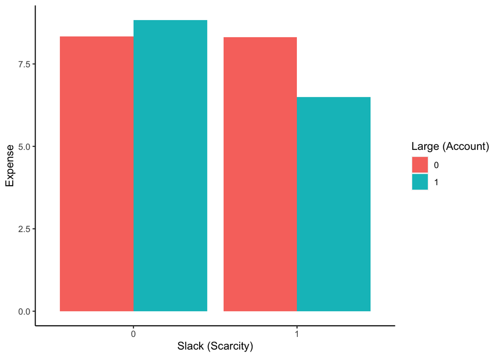

```r
ggplot(data = d, aes(y = expense, x = Slack, fill = Large)) +
  stat_summary(fun = 'mean', geom = 'bar', position = 'dodge') +
  theme(legend.direction = "vertical",
        legend.background = element_rect(fill = "transparent"),
        axis.line = element_line(),
        panel.grid = element_blank(),
        panel.background = element_blank(),
        plot.title = element_text(hjust = 0.5)) +
  labs(x = "Slack (Scarcity)", y = "Expense", fill = "Large (Account)")
```

# Step 5: Reflection

Were you able to reproduce the results you attempted to reproduce? If not, what part(s) were you unable to reproduce?

> I was able to reproduce most of the results. Although, the numbers for the confidence intervals did not match perfectly. I suspect it is either that I calculated 95% CI differently than the authors or that rounding up played a role in the mismatch.

How difficult was it to reproduce your results?

> It was not very difficult. I would say it was okay.

What aspects made it difficult? What aspects made it easy?

> The data came in as tidy format and I think it was very easy to understand data structure. Also, there was separate `Cond` variable for each group, so it was very convenient to run t-tests and calculate group-level summary statistics. I did not know which condition refers to which group at first, but once I figured that out, everything was fine in general.